# TRABAJO ESTADÍSTICA R

# Este código lee el archivo CSV, selecciona la variable ‘Global_Sales’, crea una distribución normal teórica con la misma media y desviación estándar que ‘Global_Sales’, y luego crea un gráfico de comparación.

```r
# Leemos el fichero csv
videojuegos <- read.csv("./vgsales.csv", header = TRUE)

# Mostramos las primeras líneas del conjunto de datos
head(videojuegos)
```

```
##   Rank                     Name Platform Year        Genre Publisher NA_Sales
## 1    1               Wii Sports      Wii 2006       Sports  Nintendo    41.49
## 2    2        Super Mario Bros.      NES 1985     Platform  Nintendo    29.08
## 3    3           Mario Kart Wii      Wii 2008       Racing  Nintendo    15.85
## 4    4        Wii Sports Resort      Wii 2009       Sports  Nintendo    15.75
## 5    5 Pokemon Red/Pokemon Blue       GB 1996 Role-Playing  Nintendo    11.27
## 6    6                   Tetris       GB 1989       Puzzle  Nintendo    23.20
##   EU_Sales JP_Sales Other_Sales Global_Sales
## 1    29.02     3.77        8.46        82.74
## 2     3.58     6.81        0.77        40.24
## 3    12.88     3.79        3.31        35.82
## 4    11.01     3.28        2.96        33.00
## 5     8.89    10.22        1.00        31.37
## 6     2.26     4.22        0.58        30.26
```

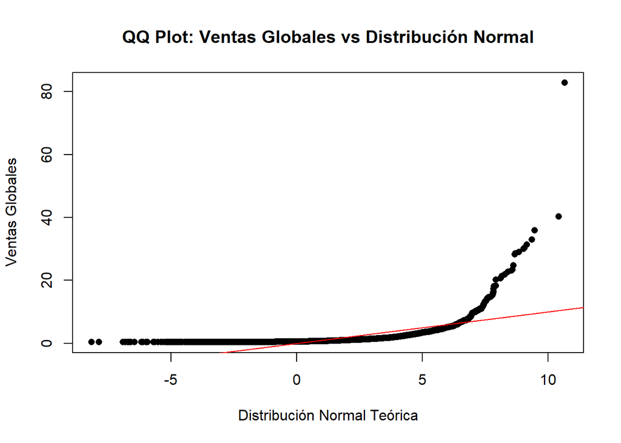

```r
# Seleccionamos la variable de interés
ventas_globales <- videojuegos$Global_Sales

# Creamos una distribución normal teórica con la misma media y desviación estándar
dist_normal <- rnorm(length(ventas_globales), mean(ventas_globales), sd(ventas_globales))

# Ordenamos ambas distribuciones para poder comparar sus percentiles
ventas_globales <- sort(ventas_globales)
dist_normal <- sort(dist_normal)

# Creamos un gráfico de comparación
plot(dist_normal, ventas_globales, main = "QQ Plot: Ventas Globales vs Distribución Normal",
     xlab = "Distribución Normal Teórica", ylab = "Ventas Globales", pch = 16)
abline(a = 0, b = 1, col = "red")
```

# Este código lee los datos desde el archivo “vgsales.csv”, elimina las filas con valores desconocidos y luego guarda los datos preprocesados en el archivo “vgsales_preprocessed.csv”. También muestra las primeras líneas del conjunto de datos preprocesado.

```r
# Función para cargar los datos
load_data <- function(filename) {
  data <- read.csv(filename, header = TRUE)
  return(data)
}

# Función para eliminar las filas con valores desconocidos
remove_na_rows <- function(data) {
  data <- data[complete.cases(data), ]
  return(data)
}

# Función para guardar los datos preprocesados
save_data <- function(data, filename) {
  write.csv(data, filename, row.names = FALSE)
}
```

```r
# Cargamos los datos
videojuegos <- load_data("./vgsales.csv")

# Eliminamos las filas con valores desconocidos
videojuegos <- remove_na_rows(videojuegos)

# Guardamos los datos preprocesados
save_data(videojuegos, "./vgsales_preprocessed.csv")

# Mostramos las primeras líneas del conjunto de datos preprocesado
head(videojuegos)
```

```
##   Rank                     Name Platform Year        Genre Publisher NA_Sales
## 1    1               Wii Sports      Wii 2006       Sports  Nintendo    41.49
## 2    2        Super Mario Bros.      NES 1985     Platform  Nintendo    29.08
## 3    3           Mario Kart Wii      Wii 2008       Racing  Nintendo    15.85
## 4    4        Wii Sports Resort      Wii 2009       Sports  Nintendo    15.75
## 5    5 Pokemon Red/Pokemon Blue       GB 1996 Role-Playing  Nintendo    11.27
## 6    6                   Tetris       GB 1989       Puzzle  Nintendo    23.20
##   EU_Sales JP_Sales Other_Sales Global_Sales
## 1    29.02     3.77        8.46        82.74
## 2     3.58     6.81        0.77        40.24
## 3    12.88     3.79        3.31        35.82
## 4    11.01     3.28        2.96        33.00
## 5     8.89    10.22        1.00        31.37
## 6     2.26     4.22        0.58        30.26
```

```r
# Leemos el fichero csv
videojuegos <- read.csv("./vgsales.csv", header = TRUE)

# Mostramos las primeras líneas del conjunto de datos
head(videojuegos)
```

```
##   Rank                     Name Platform Year        Genre Publisher NA_Sales
## 1    1               Wii Sports      Wii 2006       Sports  Nintendo    41.49
## 2    2        Super Mario Bros.      NES 1985     Platform  Nintendo    29.08
## 3    3           Mario Kart Wii      Wii 2008       Racing  Nintendo    15.85
## 4    4        Wii Sports Resort      Wii 2009       Sports  Nintendo    15.75
## 5    5 Pokemon Red/Pokemon Blue       GB 1996 Role-Playing  Nintendo    11.27
## 6    6                   Tetris       GB 1989       Puzzle  Nintendo    23.20
##   EU_Sales JP_Sales Other_Sales Global_Sales
## 1    29.02     3.77        8.46        82.74
## 2     3.58     6.81        0.77        40.24
## 3    12.88     3.79        3.31        35.82
## 4    11.01     3.28        2.96        33.00
## 5     8.89    10.22        1.00        31.37
## 6     2.26     4.22        0.58        30.26
```

```r
# Generamos números aleatorios a partir de una distribución uniforme
set.seed(123)  # Para reproducibilidad
ventas_simuladas <- runif(nrow(videojuegos), min(videojuegos$Global_Sales), max(videojuegos$Global_Sales))

# Añadimos la nueva variable al dataframe
videojuegos$Ventas_Simuladas <- ventas_simuladas

# Mostramos las primeras líneas del conjunto de datos con la variable simulada
head(videojuegos)
```

```
##   Rank                     Name Platform Year        Genre Publisher NA_Sales
## 1    1               Wii Sports      Wii 2006       Sports  Nintendo    41.49
## 2    2        Super Mario Bros.      NES 1985     Platform  Nintendo    29.08
## 3    3           Mario Kart Wii      Wii 2008       Racing  Nintendo    15.85
## 4    4        Wii Sports Resort      Wii 2009       Sports  Nintendo    15.75
## 5    5 Pokemon Red/Pokemon Blue       GB 1996 Role-Playing  Nintendo    11.27
## 6    6                   Tetris       GB 1989       Puzzle  Nintendo    23.20
##   EU_Sales JP_Sales Other_Sales Global_Sales Ventas_Simuladas
## 1    29.02     3.77        8.46        82.74        24.064885
## 2     3.58     6.81        0.77        40.24        65.304811
## 3    12.88     3.79        3.31        35.82        34.063339
## 4    11.01     3.28        2.96        33.00        73.105313
## 5     8.89    10.22        1.00        31.37        77.836886
## 6     2.26     4.22        0.58        30.26         4.132033
```

```r
# Resumen estadístico de la variable simulada
summary(videojuegos$Ventas_Simuladas)
```

```
##    Min. 1st Qu.  Median    Mean 3rd Qu.    Max.
##  0.3854 20.6770 41.3227 41.3581 61.7431 82.7352
```

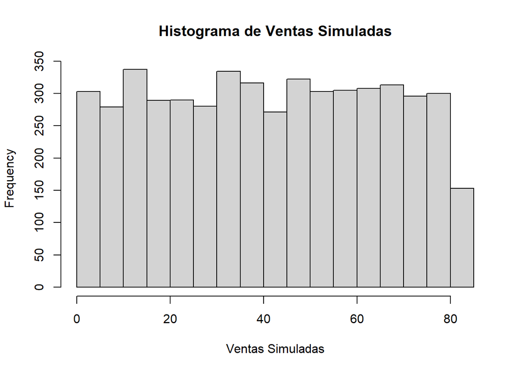

```r
# Histograma de la variable simulada
hist(videojuegos$Ventas_Simuladas, main = "Histograma de Ventas Simuladas", xlab = "Ventas Simuladas")
```